# Time Series Homework: Chapter 3 Lesson 1

Eduardo Ramirez

Loading and preparing data

```r
df <- rio::import("https://byuistats.github.io/timeseries/data/constructionequip_manu_orders_shipments.csv")

# str(df$date)

# ------------- section 1 -----------------------------------
df <- df |>
  mutate(date = lubridate::mdy(date),
         constructionequip_ord = as.numeric(constructionequip_ord), # make sure numeric for x variables
         constructionequip_ship = as.numeric(constructionequip_ship)
         ) |>
  rename(x = constructionequip_ord, y = constructionequip_ship) |> # renames columns and converts to numeric
  select(date, x, y) # re orders and or removes not selected columns

# -----------end of section 1 -----------------------

# -------------------- section 2 --------------------------

# df1 <- df |> # this makes a new df so either df before or this one is use.
#   mutate(obs = row_number()) |> # makes new column with periods
#   select(date, obs, x, y)
#
# dfx <- df |> # lone df for variable x = ord
#   mutate(obs = row_number()) |>
#   select(obs, x)
#
# dfy <- df |> # lone df for y = ship
#   mutate(obs = row_number()) |>
#   select(obs, y)

# ----------------- end of section 2 --------------------------
```

```r
df1 <- df |> # this makes a new df so either df before or this one is use.
  mutate(obs = row_number()) |> # makes new column with periods
  select(date, obs, x, y)

dfx <- df1 |> # lone df for variable x = ord
  mutate(obs = row_number()) |>
  select(date, x)

dfy <- df1 |> # lone df for y = ship
  mutate(obs = row_number()) |>
  select(date, y)
```

# Questions

## Question 1 - Context and Measurement (10 points)

The first part of any time series analysis is context. You cannot properly analyze data without knowing what the data is measuring. Without context, the most simple features of data can be obscure and inscrutable. This homework assignment will center around the series below.

Please research the time series. In the spaces below, give the data collection process, unit of analysis, and meaning of each observation for the series.

### a) Construction Equipment Manufacturing Orders and Shipments

https://fred.stlouisfed.org/graph/?g=1f4dN

**Answer**

Both x (ord) and y (ship) variables are increasing over time. So a multiplicative classical decomposition model is best. The data is collected monthly and the unit of analysis is in thousands of dollars. The data is collected by the U.S. Census Bureau and is used to measure the value of new orders and shipments for construction equipment manufacturing. The observations represent the total value of new orders and shipments in thousands of dollars for each month.

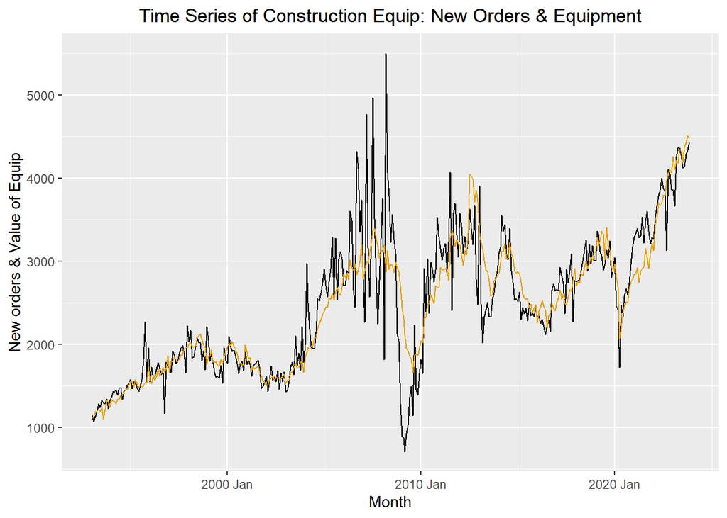

```r
# this is code for hw 3-1

# this code is same as the dfx2 & dfy2 code
df1 <- df1 |>
  mutate(index = tsibble::yearmonth(date)) |> # 3.1
  as_tsibble(index = index) |>
  select(index, date, x, y)



autoplot(df1, .vars = x) +
  geom_line(data = df1, aes(x = index, y = y), color = "#E69F00") +
  labs(
    x = "Month",
    y = "New orders & Value of Equip",
    title = "Time Series of Construction Equip: New Orders & Equipment"
  ) +
  theme(plot.title = element_text(hjust = 0.5))
```